Boxplots are useful for visualising differences between categories or groups.

Using `ggplot()`, making a boxplot is similar to a scatterplot.

If we haven’t already done it, we’d need to load the `tidyverse`:

```r
library(tidyverse)
```

To make the plot, we first choose the data we want to plot and add a pipe to the end of the line to send this data to the next command:

```r
iris %>%
```

Next we use `ggplot()` and `aes(x = ..., y = ...)` to select the columns we want to use in the data. `aes` is short for *aesthetics* which means ‘something you can see’. So the `aes()` function defines what will be able to see on the plot — the axes, and other features like color.

This time we have chosen `Species` for the x axis, because it is a *categorical* variable.

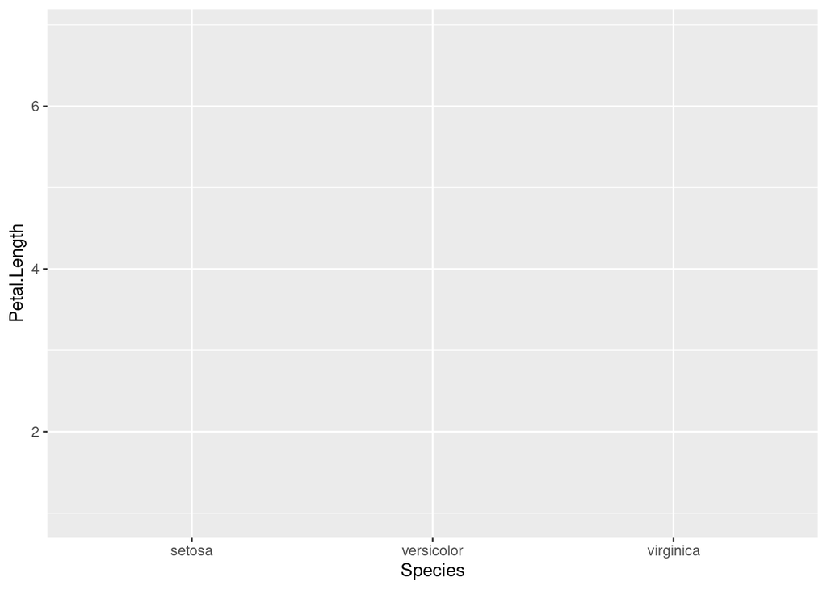

```r
iris %>%
  ggplot(aes(x = Species, y = Petal.Length))
```

You’ll notice that I used the RStudio autocomplete feature to write function and column names from our dataset.

This makes things much easier — especially for column names. If you type column names by hand it’s easy to make spelling errors or typos, and this leads to errors in R.

If we run the code so far, `ggplot()` draws the plot axes, but doesn’t add the data yet:

So far we have said *what* we want to show on our plot, but not *how* it should be shown.

To finish, we add `geom_boxplot()` which actually draws the boxes:

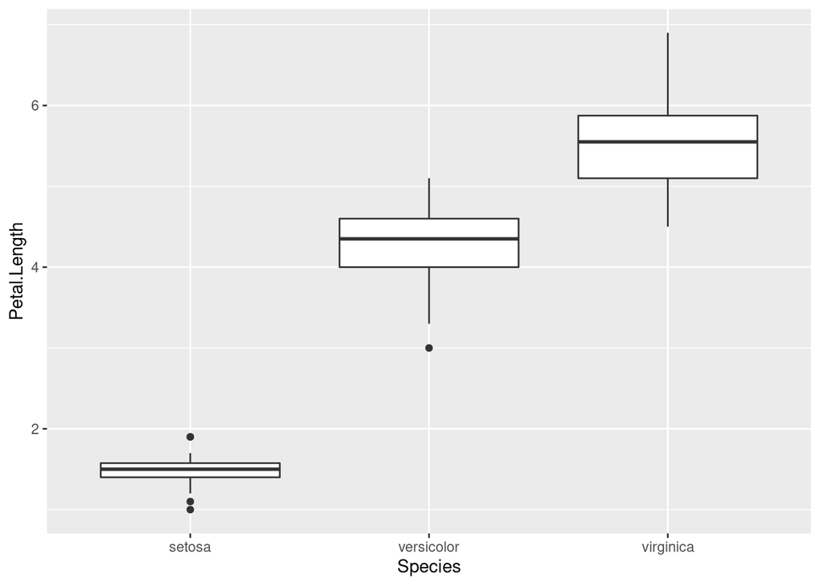

```r
iris %>%
  ggplot(aes(x = Species, y = Petal.Length)) +
  geom_boxplot()
```

Note that I used a `+` symbol to add the boxplot layer to our graph.

So, now we have a boxplot, with one box drawn for each value of `Species`.

### Interpreting boxplots

In a boxplot:

- the thick line is the median or midpoint of the data
- the height of the box indicates the [*interquartile range*](https://www.bbc.co.uk/bitesize/guides/zx7rk7h/revision/2) (IQR), so this contains 50% of the datapoints. A wider IQR indicates greater variation (spread) in a dataset.
- the whiskers vary a little bit, depending on the software you use — but normally show the range/spread of the data (The default in `ggplot()` is to show the points that are no more/less than 1.5 times the IQR above/below the top/bottom of the box.)

In this boxplot, any data point outside the range of the whiskers is described as an ‘outlying point’ or ‘outlier’. Each outlier is plotted as a dot.